# Time Series: A First Course with Bootstrap Starter

# Lesson 9-8: Spectral Density Estimation

- We estimate the spectral density by modifying the periodogram.

## Paradigm 9.8.1. Smoothing the Periodogram

- We can average the periodogram over nearby Fourier frequencies: for integer $m$,
  $$\widehat{f} (\omega) = \frac{1}{2 m +1} \sum_{j = -m}^m I (\omega +
  \lambda_j).$$
- Recall nonparametric smoothing: higher $m$ to reduce variance, but bias increases.
- More general smoothing of the periodogram:
  $$\widehat{f} (\omega) = \frac{ \sum_{\ell} W_n ((\lambda_{\ell} -
  \omega)/m) \, I (\lambda_{\ell} )}{ \sum_{\ell} W_n ((\lambda_{\ell} -
  \omega)/m) },$$
  where $W_n (x)$ is a kernel function, or *spectral window*, depending on $n$. The estimator also depends on the *bandwidth* $m$.

## Paradigm 9.8.3. Tapering the ACVF

- Recall from Remark 9.5.2 that tapering reduces variability in ACVF estimation. We can insert tapered sample ACVF into the periodogram formula:
  $$\widetilde{f} (\lambda) = \sum_{|h| \leq d} \Lambda (h/d)
  \widehat{\gamma} (h) e^{-i \lambda h},$$
  where $\Lambda (x)$ is a taper (cf. Definition 9.5.3), and $d$ is the *bandwidth*.
- We can rewrite $\widetilde{f}$ as a spectral window estimator as well, where the spectral window is proportional to $\sum_{|h| \leq d} \Lambda (h/d) e^{-i \lambda h}$.

## Example 9.8.6. Bartlett Tapered Spectral Estimator

- We apply the tapered acvf spectral estimator of Paradigm 9.8.3, using the Bartlett taper (Example 9.5.4), to the Wolfer sunspot data.
- We choose the bandwidth $d = 3 n^{1/3} = 42$, based on some asymptotic theory.
- We plot in logs, and so remove the frequency zero value.

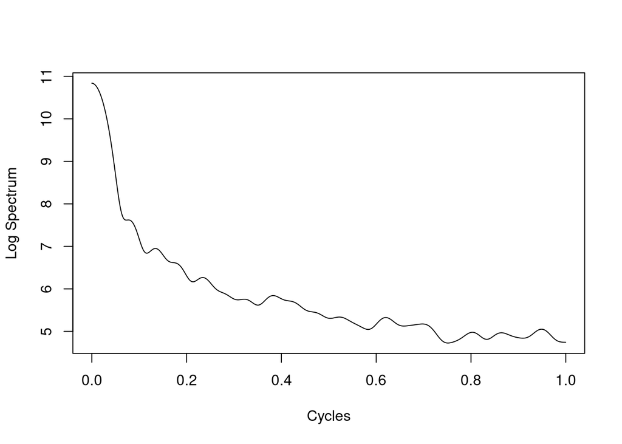

```r
wolfer <- read.table("wolfer.dat")
wolfer <- ts(wolfer[,1],start=1749,frequency=12)
data <- wolfer
n <- length(data)
d <- 3*floor(n^{1/3})
acfs.sample <- NULL
mu.hat <- sum(data)/n
for(k in 0:(n-1))
{
    acf.sample <- sum((data[1:(n-k)]-mu.hat)*(data[(k+1):n]-mu.hat))/n
    acfs.sample <- c(acfs.sample,acf.sample)
}
grid <- 10000
lambda <- seq(0,grid)*pi/grid
pgram <- cos(0*lambda)*acfs.sample[1]
for(h in 1:(n-1))
{
    pgram <- pgram + 2*(max(1-h/d,0))*cos(h*lambda)*acfs.sample[h+1]
}
pgram <- ts(pgram[-1],start=0,frequency=grid)
plot(log(pgram),xlab="Cycles",ylab="Log Spectrum")
```